# Section 3: Structure analyses

*Note: the analyses in this notebook expect certain files to have already been created by the preprocessing.Rmd and structure.ipynb notebooks*

```r
library(tidyverse)
library(lme4)
library(ggthemes)
library(tm)
library(tidyboot)
library(xtable)
library(entropy)
library(useful)
library(viridis)
library(broom)
library(broom.mixed)

library(ggthemes)
library(cowplot)

source('../utils/analysis_helpers.R')
```

# 3 | RESULTS: CHARACTERIZING THE DYNAMICS OF STRUCTURE

## Section 3.1: The effect of matcher feedback on reduction

```r
# Import uncollapsed version of data to examine matcher
message_df = read_csv('../../data/tangramsSequential.csv') %>%
  mutate(numRawWords = str_count(contents, "\\S+"))

meta_message_df = message_df %>%
  group_by(gameid, trialNum, repetitionNum, intendedName) %>%
  summarize(correct = mean(correct), numRawWords = sum(numRawWords))

listenerMsgs <- message_df %>%
  group_by(gameid, repetitionNum, role, intendedName) %>% #taskVersion
  summarize(individualM = n()) %>%
  ungroup() %>%
  complete(gameid, intendedName, repetitionNum, role, fill = list(individualM = 0)) %>%
  spread(role, individualM)  %>%
  left_join(meta_message_df)

listenerReduction <- listenerMsgs %>%
   group_by(repetitionNum, gameid) %>%
   summarize(matcherTalks = sum(matcher) > 0) %>%
   group_by(repetitionNum) %>%
   tidyboot_mean(matcherTalks) %>%
   mutate(measure = '# listener messages')
```

Statistics for reduction in matcher message rates

```r
listenerMsgs %>%
  mutate(matcherBin = matcher > 0) %>%
  glmer(matcherBin ~ repetitionNum +
          (1 + repetitionNum | gameid) +
          (1  | intendedName),
        data = .,
        family = 'binomial') %>%
  tidy()
```

| effect | group | term | estimate | std.error | statistic | p.value |
| --- | --- | --- | --- | --- | --- | --- |
| fixed | NA | (Intercept) | -0.94225855 | 0.22415201 | -4.203659 | 2.626349e-05 |
| fixed | NA | repetitionNum | -0.84499038 | 0.09323433 | -9.063082 | 1.268155e-19 |
| ran_pars | gameid | sd__(Intercept) | 1.45213808 | NA | NA | NA |
| ran_pars | gameid | cor__(Intercept).repetitionNum | -0.71523735 | NA | NA | NA |
| ran_pars | gameid | sd__repetitionNum | 0.47685562 | NA | NA | NA |
| ran_pars | intendedName | sd__(Intercept) | 0.06586596 | NA | NA | NA |

### Visualization of matcher rates (Fig. 2B)

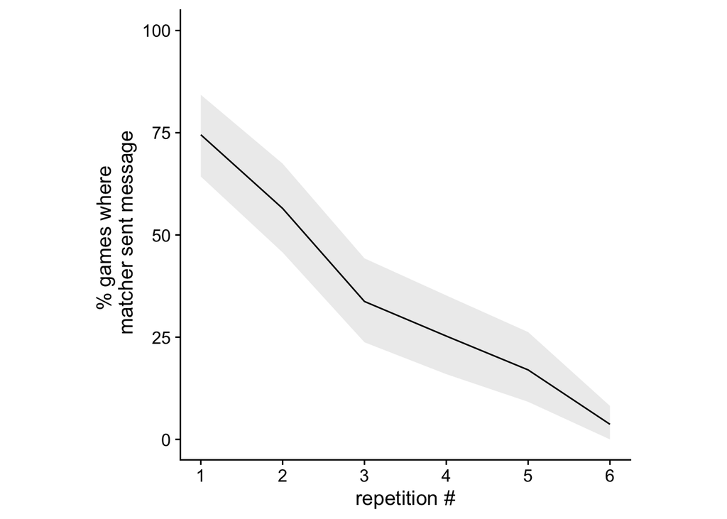

```r
ggplot(listenerReduction, aes(x = repetitionNum, y = mean*100)) +
  geom_ribbon(aes(ymax = 100 * ci_upper,
                  ymin = 100 * ci_lower),
              alpha = 0.1, color = F) +
  geom_line() +
  ylab('% games where \n matcher sent message') +
  xlab('repetition #') +
  ylim(0,100) +
  scale_x_continuous(breaks = round(seq(1, 6, by = 1),1)) +
  theme_cowplot() +
  theme(aspect.ratio = 1)
```

```r
ggsave('../../writing/figs/listenerResponses.pdf',
       height = 8, width = 12, units = 'cm', useDingbats = F)
```

### mini-analysis of what is actually contained in listener response messages

```r
# Count question marks
message_df %>%
  filter(role == 'matcher') %>%
  mutate(containQ = str_detect(contents, "\\?")) %>%
  group_by(containQ) %>%
  tally() %>%
  ungroup() %>%
  mutate(proportion = n / sum(n))
```

| containQ | n | proportion |
| --- | --- | --- |
| FALSE | 254 | 0.506986 |
| TRUE | 247 | 0.493014 |

### Were directors sensitive to ground-truth accuracy feedback?

```r
# Extract reduction in response to feedback for
# both repetition and trial-by-trial baseline
feedback <- listenerMsgs %>%
  mutate(matcherBin = matcher > 0) %>%
  group_by(gameid) %>% arrange(gameid, trialNum) %>%
  mutate(trial_prevcorrect = lag(correct),
         trial_reduction = log(numRawWords/lag(numRawWords))) %>%
  group_by(gameid, intendedName) %>% arrange(gameid, repetitionNum) %>%
  mutate(rep_prevcorrect = lag(correct),
         rep_reduction = log(numRawWords/lag(numRawWords))) %>%
  gather(comparison, val, trial_prevcorrect : rep_reduction) %>%
  separate(comparison, into = c('comparison', 'metric')) %>%
  spread(metric, val) %>%
  group_by(gameid) %>%
  # only look at games where at least one error was made
  # (otherwise no rounds after error to compare)
  filter(sum(prevcorrect == 0, na.rm = T) > 0) %>%
  ungroup() %>%
  filter(!is.na(prevcorrect)) %>%
  filter(!is.na(reduction)) %>%
  mutate(prevcorrectFactor = factor(ifelse(prevcorrect == 1, 'correct', 'incorrect')),
         comparisonNumeric = ifelse(comparison == "rep", 1, 0))
```

```r
feedback %>%
  filter(repetitionNum == 1) %>%
  group_by(matcherBin) %>%
  summarize(m = 1 - mean(correct))
```

| matcherBin | m |
| --- | --- |
| FALSE | 0.2305516 |
| TRUE | 0.1970803 |

```r
tab <- table((feedback %>% filter(repetitionNum == 1))$matcherBin,
             (feedback %>% filter(repetitionNum == 1))$correct)

chisq.test(tab)
```

```
##
##  Pearson's Chi-squared test with Yates' continuity correction
##
## data:  tab
## X-squared = 0.55766, df = 1, p-value = 0.4552
```

```r
feedback %>%
  filter(comparison == 'rep') %>%
  lmer(reduction ~ 1 + prevcorrect + I(repetitionNum) +
         (1 + prevcorrect + I(repetitionNum) | gameid),
       data = .,
      control=lmerControl(optimizer="bobyqa",optCtrl=list(maxfun=100000))) %>%
  tidy()
```

| effect | group | term | estimate | std.error | statistic |
| --- | --- | --- | --- | --- | --- |
| fixed | NA | (Intercept) | -0.60612048 | 0.06270022 | -9.666960 |
| fixed | NA | prevcorrect | -0.28130743 | 0.03933655 | -7.151299 |
| fixed | NA | I(repetitionNum) | 0.13530297 | 0.01316522 | 10.277304 |
| ran_pars | gameid | sd__(Intercept) | 0.43693048 | NA | NA |
| ran_pars | gameid | cor__(Intercept).prevcorrect | 0.04281766 | NA | NA |
| ran_pars | gameid | cor__(Intercept).I(repetitionNum) | -0.93129435 | NA | NA |
| ran_pars | gameid | sd__prevcorrect | 0.18353288 | NA | NA |
| ran_pars | gameid | cor__prevcorrect.I(repetitionNum) | -0.40255590 | NA | NA |
| ran_pars | gameid | sd__I(repetitionNum) | 0.09741238 | NA | NA |
| ran_pars | Residual | sd__Observation | 0.66336454 | NA | NA |

Test interaction with traditional regression b/c even minimal lmer does not converge

```r
lm(reduction ~ prevcorrectFactor * comparison, data = feedback) %>%
  tidy()
```

| term | estimate | std.error | statistic | p.value |
| --- | --- | --- | --- | --- |
| (Intercept) | -0.3360190 | 0.01288019 | -26.088054 | 3.097790e-145 |
| prevcorrectFactorincorrect | 0.1733442 | 0.03782135 | 4.583236 | 4.633446e-06 |
| comparisontrial | 0.3319098 | 0.01744683 | 19.024072 | 2.626328e-79 |
| prevcorrectFactorincorrect:comparisontrial | -0.3249304 | 0.05235890 | -6.205829 | 5.655129e-10 |

Backup Bayesian mixed-effects model mentioned in footnote

```r
library(brms)
library(rstan)
brm(reduction ~ prevcorrectFactor * comparison +
               (1 + prevcorrectFactor * comparison | gameid),
    chains = 1,
    iter = 5000,
    data = feedback) %>%
  tidy()
```

[output not shown]

| effect | component | group | term | estimate | std.error | conf.low | conf.high |
| --- | --- | --- | --- | --- | --- | --- | --- |
| fixed | cond | NA | (Intercept) | -0.335899430 | 0.013480156 | -0.3616640351 | -0.30919800 |
| fixed | cond | NA | prevcorrectFactorincorrect | 0.171064916 | 0.040139444 | 0.0913475059 | 0.24816212 |
| fixed | cond | NA | comparisontrial | 0.332253235 | 0.017370479 | 0.2971976721 | 0.36528112 |
| fixed | cond | NA | prevcorrectFactorincorrect:comparisontrial | -0.308969557 | 0.056548792 | -0.4141479805 | -0.19686094 |
| ran_pars | cond | gameid | sd__(Intercept) | 0.024800143 | 0.017498127 | 0.0008721695 | 0.06597973 |
| ran_pars | cond | gameid | sd__prevcorrectFactorincorrect | 0.082624333 | 0.050302877 | 0.0047751100 | 0.18874336 |
| ran_pars | cond | gameid | sd__comparisontrial | 0.018387418 | 0.015139282 | 0.0008864498 | 0.05890226 |
| ran_pars | cond | gameid | sd__prevcorrectFactorincorrect:comparisontrial | 0.160796012 | 0.074785286 | 0.0160732652 | 0.30181147 |
| ran_pars | cond | gameid | cor__(Intercept).prevcorrectFactorincorrect | -0.003574358 | 0.445146991 | -0.8184804122 | 0.82944816 |
| ran_pars | cond | gameid | cor__(Intercept).comparisontrial | -0.258060746 | 0.466526140 | -0.9387597652 | 0.70174880 |

[output cut: 5 more lines]

Make Fig. 2C

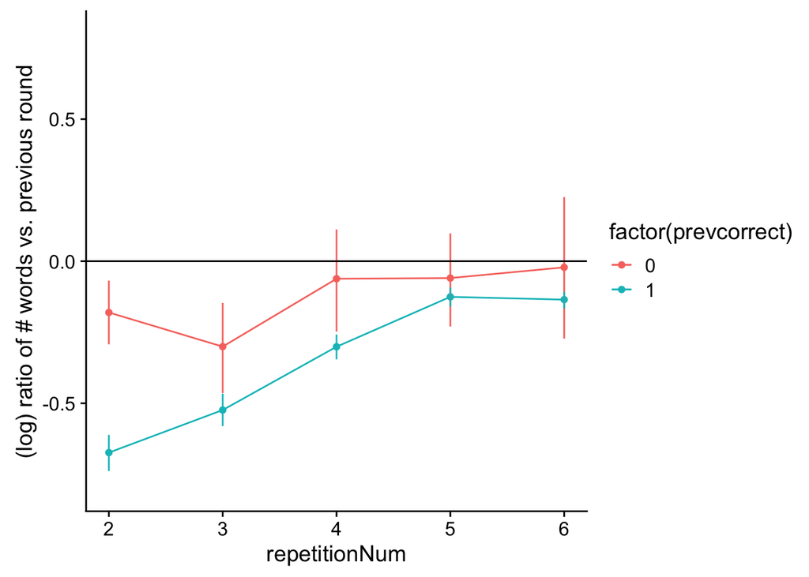

```r
feedback.toplot <- feedback %>%
  filter(comparison == 'rep') %>%
  group_by(repetitionNum, prevcorrect) %>%
  tidyboot_mean(column = reduction, na.rm =T, nboot = 1000)
feedback.toplot %>%
  ungroup() %>%
  ggplot(aes(x = repetitionNum, y = empirical_stat, color = factor(prevcorrect))) +
    geom_point() +
    geom_line() +
    geom_errorbar(aes(ymin = ci_lower, ymax = ci_upper),
                  width = 0, position = 'dodge') +
    geom_hline(aes(yintercept = 0)) +
    theme_cowplot()  +
    theme(aspect.ratio = 1) +
    ylab('(log) ratio of # words vs. previous round') +
    ylim(-0.8, 0.8)
```

```r
ggsave('../../writing/figs/responseToFeedback.pdf',
       height = 8, width = 16, units = 'cm', useDingbats = F)
```

## Section 3.2 | Breaking down the structure of reduction

### Pure reduction in utterance length

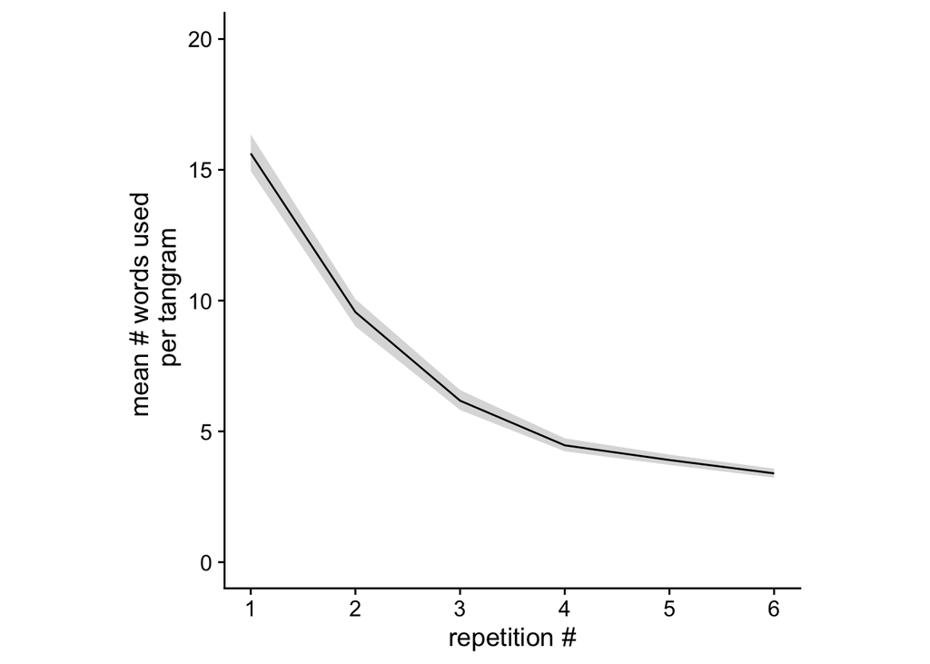

```r
to.plot <- tagged_df %>%
   group_by(repetitionNum) %>%
   tidyboot_mean(numWords, na.rm = T, nboot = 500)
to.plot %>%
   mutate(measure = '# words per tangram') %>%
   ggplot(aes(x = repetitionNum, y = empirical_stat)) +
    geom_ribbon(aes(ymax = ci_upper, ymin = ci_lower), alpha= 0.2) +
    geom_line() +
    xlab('repetition #') +
    ylab('mean # words used \n per tangram') +
    scale_x_continuous(breaks = round(seq(1, 6, by = 1),1)) +
    ylim(c(0, 20)) +
    theme_cowplot()  +
    theme(aspect.ratio = 1)
```

```r
ggsave('../../writing/figs/reduction.pdf',
        height = 8, width = 12, units = 'cm', useDingbats = F)
```

Statistics:

```r
tagged_df %>%
   group_by(gameid, trialNum, repetitionNum, intendedName) %>%
   summarize(numRawWords = sum(numWords)) %>%
  lmer(log(numRawWords) ~ poly(repetitionNum,2) +
               (1 + repetitionNum | gameid) +
               (1 + repetitionNum | intendedName),
       data = .,
       control=lmerControl(optimizer="bobyqa",optCtrl=list(maxfun=100000))) %>%
  tidy()
```

| effect | group | term | estimate | std.error | statistic |
| --- | --- | --- | --- | --- | --- |
| fixed | NA | (Intercept) | 1.5228314 | 0.0727931 | 20.92000 |
| fixed | NA | poly(repetitionNum, 2)1 | -40.3028958 | 2.2252991 | -18.11123 |
| fixed | NA | poly(repetitionNum, 2)2 | 12.7951039 | 0.6118413 | 20.91245 |
| ran_pars | gameid | sd__(Intercept) | 0.5467670 | NA | NA |
| ran_pars | gameid | cor__(Intercept).repetitionNum | -0.7270544 | NA | NA |
| ran_pars | gameid | sd__repetitionNum | 0.1279418 | NA | NA |
| ran_pars | intendedName | sd__(Intercept) | 0.2400619 | NA | NA |
| ran_pars | intendedName | cor__(Intercept).repetitionNum | -0.5337585 | NA | NA |
| ran_pars | intendedName | sd__repetitionNum | 0.0281252 | NA | NA |
| ran_pars | Residual | sd__Observation | 0.6118141 | NA | NA |

Supplemental check – we examined the number of total words a director produced for a tangram, but at the beginning when there is more back-and-forth dialogue, this set of words also includes responses to the matcher. Does the number of words in the *initial* description go down over time, too? (i.e. the description produced before the listener chimes in).

```r
message_df %>%
  group_by(gameid, trialNum) %>%
  mutate(uttNumInTrial = row_number()) %>%
  filter(role == 'matcher') %>%
  summarize(firstListenerUtt = first(uttNumInTrial)) %>%
  right_join(message_df) %>%
  mutate(firstListenerUtt = ifelse(is.na(firstListenerUtt), 1000, firstListenerUtt)) %>%
  group_by(gameid, trialNum, repetitionNum) %>%
  mutate(uttNumInTrial = row_number()) %>%
  filter(uttNumInTrial < firstListenerUtt) %>%
  summarize(m = sum(numRawWords)) %>%
  group_by(repetitionNum) %>%
  summarize(m = mean(m))
```

| repetitionNum | m |
| --- | --- |
| 1 | 14.022634 |
| 2 | 9.017617 |
| 3 | 5.907963 |
| 4 | 4.422764 |
| 5 | 3.860887 |
| 6 | 3.386935 |

### Table 1

What are the unigrams/bigrams/trigrams that drop the most in frequency across whole data set?

```r
makeNGramTable(15)
```

```
## \begin{table*}[t]
## \centering
## \begin{tabular}{|r||l|l|l|}
##   \hline
##  & unigrams & bigrams & trigrams \\
##   \hline
## \#1 & a & look like & look like a \\
##   \#2 & the & like a & look like -PRON- \\
##   \#3 & -PRON- & to the & to the right \\
##   \#4 & like & this one & like a person \\
##   \#5 & look & the right & to the left \\
##   \#6 & be & the left & one look like \\
##   \#7 & on & like -PRON- & this one look \\
##   \#8 & one & on the & like -PRON- be \\
##   \#9 & with & with a & this one be \\
##   \#10 & to & a person & -PRON- look like \\
##   \#11 & and & -PRON- be & look like someone \\
##   \#12 & right & on top & diamond on top \\
##   \#13 & this & a diamond & in the air \\
##   \#14 & of & in the & on top of \\
##   \#15 & head & one look & a diamond on \\
##    \hline
## \end{tabular}
## \caption{Top 10 unigrams and bigrams with the highest reduction}
## \label{tab:words}
## \end{table*}
```

### Reduction in parts of speech (Fig. 3)

examine reduction in different parts of speech

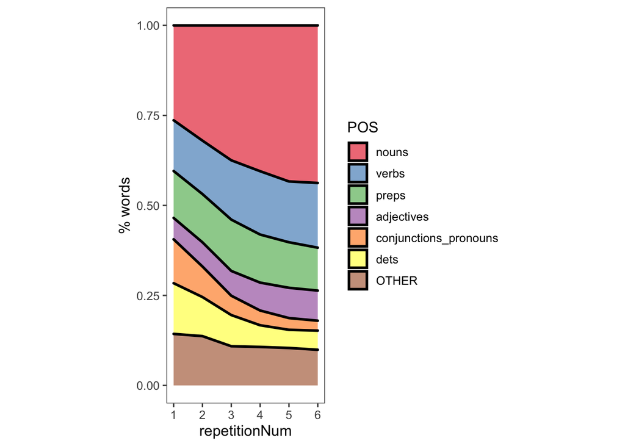

```r
read_csv('../outputs/posTagged_tangramsSequential_collapsed.csv') %>%
  group_by(repetitionNum) %>%
  summarize(numWords = sum(numWords),
            nouns = sum(NOUNcount)/sum(numWords),
            verbs = sum(VERBcount)/sum(numWords),
            dets= sum(DETcount)/sum(numWords),
            preps = sum(ADPcount)/sum(numWords),
            conjunctions_pronouns = (sum(CCONJcount) + sum(SCONJcount) +
                                       sum(PRONcount))/sum(numWords),
            adjectives = sum(ADJcount)/sum(numWords)) %>%
  mutate(OTHER = (1 - nouns - verbs - dets -conjunctions_pronouns -
                      preps - adjectives)) %>%
  gather(POS, prop, nouns:OTHER) %>%
  mutate(POS = factor(POS, levels = c('nouns',  'verbs', 'preps', 'adjectives',
                               'conjunctions_pronouns', 'dets', 'OTHER'))) %>%
  select(repetitionNum, POS, prop) %>%
  ggplot(aes(x = repetitionNum, y = prop, fill = POS)) +
    geom_area(alpha=0.6 , size=1, colour="black") +
    scale_fill_brewer(palette = "Set1") +
    ggthemes::theme_few() +
    scale_x_continuous(breaks = c(1,2,3,4,5,6))+
    theme(aspect.ratio = 2.5) +
    ylab('% words')
```

```r
ggsave('../../writing/figs/posChange.pdf',
        height = 8, width = 16, units = 'cm', useDingbats = F)
```

Explicitly look at reduction for each POS.

```r
posReduction <- tagged_df %>%
  group_by(gameid, repetitionNum) %>%
  summarize(numWords = sum(numWords),
            numMessages = length(gameid),
            nouns = sum(NOUNcount),
            verbs = sum(VERBcount),
            dets= sum(DETcount),
            pronouns = sum(PRONcount),
            preps = sum(ADPcount),
            adverbs = sum(ADVcount),
            conjunctions = sum(CCONJcount) + sum(SCONJcount),
            adjectives = sum(ADJcount)) %>%
  gather(POS, count, nouns:adjectives) %>%
  select(gameid, repetitionNum, POS, count) %>%
  # Need to put in ids to spread
  rowwise() %>%
  mutate(id = row_number(),
         repetitionNum = paste0('rep', repetitionNum, collapse = '')) %>%
  spread(repetitionNum, count) %>%
  # Compute % reduction from first to last round
  mutate(diffPct = (rep1 - rep6)/rep1) %>%
  group_by(POS) %>%
  # Filter out handful of people who skipped first round w/ negative %...
  filter(diffPct >= 0) %>%
  filter(POS != "OTHER") %>%
  mutate(cat = case_when(POS %in% c('dets', 'pronouns', 'preps', 'conjunctions') ~ 'closed',
                         POS == 'adverbs' ~ '?',
                         TRUE ~ 'open'),
         cat = factor(cat, levels = c('closed', '?', 'open'))) %>%
  # rearrange
  transform(POS=reorder(POS, -diffPct))

posReduction.boot <- posReduction %>%
  group_by(POS, cat) %>%
  # Take mean & se over participants
  tidyboot_mean(column = diffPct, na.rm = T)
```

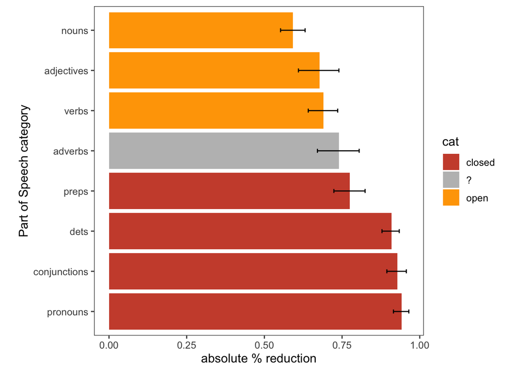

```r
ggplot(posReduction.boot, aes(x = POS, y = mean, fill = cat)) +
  geom_bar(stat = 'identity') +
  geom_errorbar(aes(ymax = ci_upper, ymin = ci_lower), width = .1)+
  ylab("absolute % reduction") +
  xlab("Part of Speech category")  +
  theme(axis.text.x = element_text(angle = 90, hjust = 1)) +
  scale_fill_manual(values=c('tomato3', 'gray', 'orange')) +
  theme_few() +
  coord_flip() +
  theme(aspect.ratio = 1)
```

```r
ggsave('../../writing/figs/posReduction.pdf',
        height = 8, width = 16, units = 'cm', useDingbats = F)
```

```r
detReductionRate <- (posReduction.boot %>% filter(POS == 'dets'))$mean * 100
conjReductionRate <- (posReduction.boot %>% filter(POS == 'conjunctions'))$mean * 100
pronounReductionRate <- (posReduction.boot %>% filter(POS == 'pronouns'))$mean * 100
nounReductionRate <- (posReduction.boot %>% filter(POS == 'nouns'))$mean * 100

cat('determiners reduce by', detReductionRate, '\n')
```

```
## determiners reduce by 90.88929
```

```r
cat('conjunctions reduce by', conjReductionRate, '\n')
```

```
## conjunctions reduce by 92.78312
```

```r
cat('pronouns reduce by', pronounReductionRate, '\n')
```

```
## pronouns reduce by 94.19429
```

```r
cat('nouns reduce by', nounReductionRate, '\n')
```

```
## nouns reduce by 59.1964
```

Stats for open class vs. closed class

```r
posReduction %>%
  filter(cat != '?') %>%
  lmer(diffPct ~ cat + (1 + cat | gameid),
       data = .) %>%
  tidy()
```

```
## boundary (singular) fit: see ?isSingular
```

| effect | group | term | estimate | std.error | statistic |
| --- | --- | --- | --- | --- | --- |
| fixed | NA | (Intercept) | 0.88442093 | 0.01317495 | 67.12898 |
| fixed | NA | catopen | -0.23965577 | 0.01615072 | -14.83870 |
| ran_pars | gameid | sd__(Intercept) | 0.08303129 | NA | NA |
| ran_pars | gameid | cor__(Intercept).catopen | 1.00000000 | NA | NA |
| ran_pars | gameid | sd__catopen | 0.06190354 | NA | NA |
| ran_pars | Residual | sd__Observation | 0.17015245 | NA | NA |

### Reduction in syntactic units (+ Supplemental Fig. 10)

Get list of all words dropped on each round…

```r
syntactic <- read_csv('../outputs/permuted_dependency_distribution.csv')
syntactic %>%
  filter(repetitionNum == 'avg') %>%
  group_by(baselineName) %>%
  summarize(lower = min(value), upper = max(value))
```

| baselineName | lower | upper |
| --- | --- | --- |
| function | 3.028129 | 3.084510 |
| random | 2.903291 | 2.986348 |
| true | 2.767219 | 2.767219 |

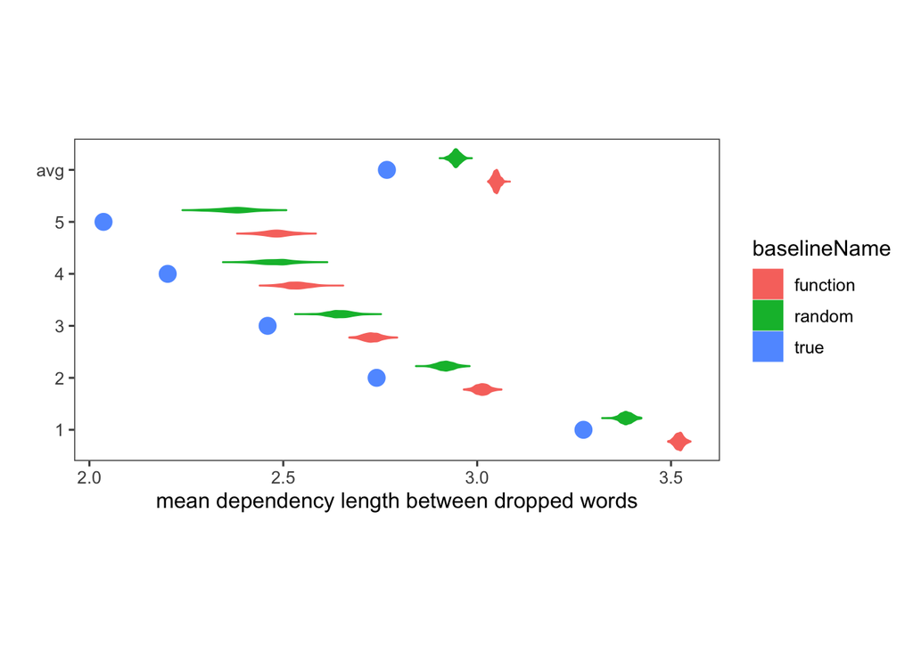

```r
syntactic %>%
  mutate(repetitionNum = fct_rev(factor(paste0('repetition ', repetitionNum)))) %>%
  ggplot(aes(x = repetitionNum, y= value, fill=baselineName, color = baselineName)) +
    geom_point(data = subset(syntactic, baselineName == 'true'), size = 4) +
    geom_violin(data = subset(syntactic, baselineName != 'true'))  +
    theme_few() +
    ylab('mean dependency length between dropped words') +
    xlab('') +
    coord_flip() +
    #scale_x_continuous(breaks = NULL) +
    theme(aspect.ratio = 1/2)
```

```r
ggsave('../../writing/figs/syntactic_reduction_baselines.pdf',
       height = 8, width = 16, units = 'cm', useDingbats = F)
```